# Your Digest for Friday, Aug 25, 2023 11:59 PM

> The immune phase is marked by production of antibodies and *excretion of leptospires in urine.*  
> [!INFO] Why leptospirosis causes **conjugated** hyperbilirirubinaemia:  
> Our results suggest that pathogenic leptospires invade the intercellular junctions of host hepatocytes, and this invasion contributes in the *disruption of the junction*. Subsequently, bile leaks from bile canaliculi and **jaundice** occurs immediately. - [Source](https://pubmed.ncbi.nlm.nih.gov/24945433/)  
> **"Question mark" hook** on bacterium - characteristic feature.  
> | B1 - Thiamine | | **Beri Beri** (infantile beri beri / Adult beri beri), **Wernicke-Korsakoff** syndrome | |  
> | B3 - Niacin | Synthesis of carbs, proteins and fatty acids | Pellagra ('raw skin'): photosensitive dermatitis (Casal Collar) and also FOUR D'S (diarrhoea, dementia, dermatitis, death) | Grains, legumes, seeds, animal liver |
- **Triad** of ophthalmoplegia, ataxia, confusion, + nystagmus + lower limb polyneuropathy.

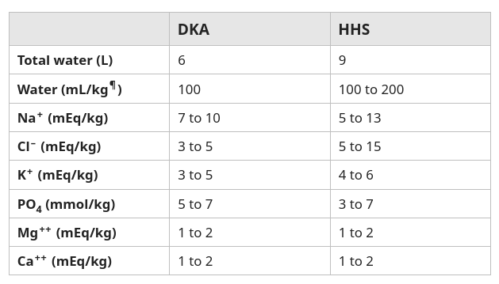

*Megaloblasts present in bone marrow* **AND** *Oval macrocytes on the blood smear*.

> Megaloblastic states result from defective DNA synthesis. However, RNA synthesis continues, resulting in a large cell with a large nucleus.  
> Therefore, *characteristically*, megaloblasts in the bone marrow have *immature nuclei* **compared to the degree of cytoplasmic maturation**.  
> Howell-Jolly bodies (DNA remnants) may be present.

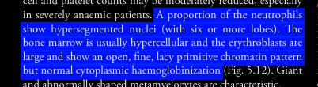

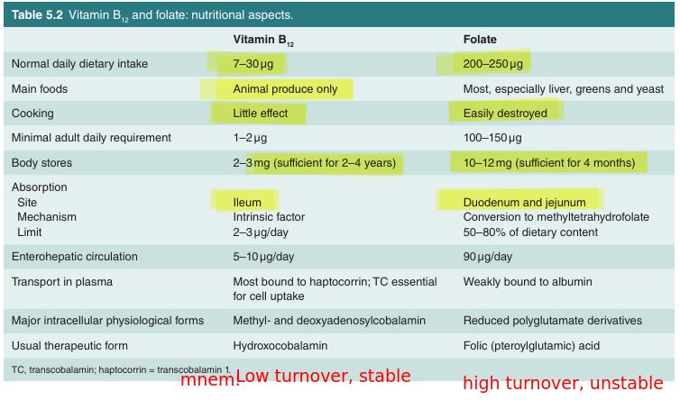

> 1. When methylene THF is used for this purpose, it is converted to *methyl*-THF. This is unusable.
3. The *methyl* THF is recycled to THF so that it can be reconverted to methylene THF and more DNA can be made.
4. This recylding of methyl THF requires action of the *methionine synthase* reaction for **which B12 is a cofactor.**  
   Deficiency of B12 and Folate both result in **deficiency of methylene THF** and therefore, defiency of DNA sythesis -> **megaloblastic anaemia**  
   B12 = cobalamin.  
   B12 is only made by some microorganisms; humans are **dependent on animal sources**.  
   *parietal cells destroyed*  
   Pathophysiology : Autoimmune destruction of parietal cells, which secrete IF, or the development of auto-antibodies targeted against IF itself.  
   Folate deficiency may cause glossitis, diarrhoea and depressions.[Source](https://www.msdmanuals.com/professional/nutritional-disorders/vitamin-deficiency,-dependency,-and-toxicity/folate-deficiency?query=Folate%20Deficiency)

## Treatment of B12 and folate deficiency

If large doses of folate are given in B12 deficiency, **neuropathy can be worsened!**.  
B9 (folate) should not be given alone unless B12 deficiency is excluded.  
B12 is given IM and B9 is given orally.

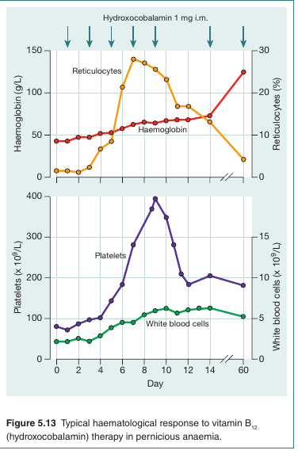

# Reticulocytes and assessment of erythropoiesis

## Erythropoiesis

The first recognisable RBC precursor is the **pronormoblast**.  
Once the nucleus is extruded, a reticulocyte results. *They only have cytoplasmic RNA*. No DNA.  
Reticulocytes still have RNA so they can still synthesize haemoglobin. They circulate in the blood for 1-2 days before maturing and losing all RNA.

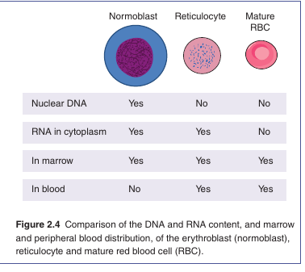

In intact erythropoiesis, reticulocyte count increases in proportion to the anaemia.  
Erythropoiesis is stimulated by EPo which is produced by the **peritubular, interstitial cells** of the kidney in response to reduced oxygen delivery.  
**Timescale**: after acute haemorrhage, *EPO increases by 6 hours*, *retic count begins to increase in 2-3 days and peaks by 6-10 days* and stays elevated until the Hb returns to normal.  
**Normal retic count** - 0.5 - 2.5%

[figure not shown]

## Mechanism of EPo

EPo increases the number of progenitor cells committed to erythrypoiesis.  
In the chronic state, there is anatomical expansion of erythropoiesis into fatty marrow and even into extramedullar sites.

| Primary MF | Secondary MF |
| --- | --- |
| Mutation -> Activation of *JAK-STAT Pathway* -> increased cell production - Cont; *50% of cases are associated with JAK/STAT mutations*; 25% have CALR mutation | Develops from essential thrombocythemia or polycythemia vera |
| Increased megakaryocytes --> they secrete *Fibroblast stimulating factor* -> *marrow fibrosis* --> Extramedullary haematopoiesis |  |
| EMH isn't able to compensate for marrow loss --> **pancytopaenia** |  |
| Epidemiology: Middle aged and older adult; age = 67; Least common of the myeloproliferative disorders |  |
| **SYmptoms:** Bone pain, fever,**itching**, weight loss, **hepatosplenomegaly** (EMH), frequent infections(↓WBC), DVT, Pulmonary embolism (**↑PLT**) |  |
| **Blood picture**: *Leukoerythroblastic blood picture*, immature red blood cells, **Marrow biopsy**: initially increased cellularity, later fibrosis |  |
| **FBC**: leukocytosis and thrombocytosis at presentation but later leucopenia and thrombocytopenia |  |
| **Mx**: Ruxolitinib inhibits JAK STAT pathway (shown to reduce spleen size), bone marrow transplant may be curative in some, blood transfusions and Erythropoietin |  |

## Diagnosis

dry tap on bone marrow aspiration  
biopsy - increased megakaryocytes

3. Median survival 4-5 years

# Malignant myeloma presentation

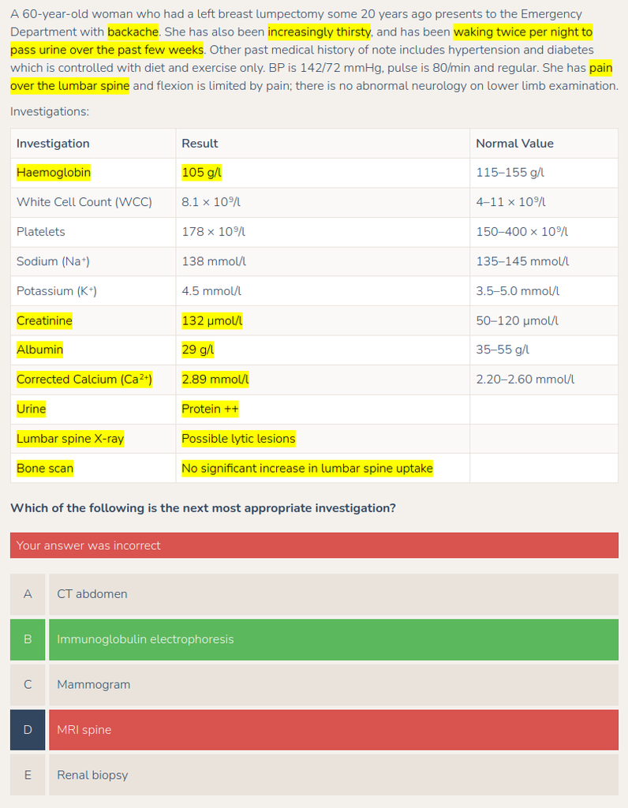

- symmetrical polyarthritis
> - IgA nephropathy
> - infective endocarditis associated nephropathy  
>   #2022GM-MAY Q30  
>   [!NOTE] Modern classification of glomerulonpehritis  
>   **A more modern way to classify glmoerulonephritis:**  
>   [Source](https://www.ncbi.nlm.nih.gov/books/NBK560644/)
> 1. **Immune-complex GN** - IgA nephropathy, IgA vasculitis, infection-related GN, lupus nephritis, and fibrillary GN with polyclonal Ig deposits
> 2. **Pauci-immune GN** - PR3-ANCA GN, MPO-ANCA GN, and ANCA-negative GN
> 3. **Anti-glomerular basement membrane (GBM) GN** - Anti-GBM GN
> 4. **Monoclonal Ig GN** - Proliferative GN with monoclonal Ig deposits, monoclonal Ig deposition disease, fibrillary GN with monoclonal Ig deposits, and immunotactoid glomerulopathy
> 5. **C3 glomerulopathy** - C3 glomerulonephritis, dense deposit disease

## Post streptococcal glomerulonephritis PSGN

#2023BSQ Q24  
[[Nephrology miscellaneous#Overview of renal histology and function]]

**Pathophysiology:**  
Overview:  
Autoimmune response to *nephritogenic* GABHS (strep. pyogenes) -> Immune *complexes* formed and deposited in glomeruli -> activation of *alternate* complement pathway -> recruitment of *inflammatory cells* -> glomerular injury.

Details:  
It's not known whether immune complexes are formed in situ at glomeruli or formed elsewhere and deposited.

**Histology**

- involvement of the complement pathway is evidenced by finding **C3 and IgG** with IF stains. They have a *granular* appearance producing a *starry sky* pattern.
- They are components of the "immune complexes".
- If we use electron microscopy, we see that the immune complexes are dome shaped **sub-*epi*thelial** deposits (aka "*humps*"). These are **CHARACTERISTIC** of PSGN. Subendothelial humps are also seen.
- **Renal biopsy** in PSGN shows diffuse, florid, acute inflammation in the glomerulus (*without necrosis* but occasionally with cellular *crescents*) with **neutrophils** and deposition of IgG and complement

> There is increased cellularity of the glomerular tufts, caused both by *proliferation* and *swelling* of **endothelial** and **mesangial** cells and by *infiltrating* **neutrophils** and monocytes.

> [!INFO]
> - **Subepithelial humps** -> epithelial damage and proteinuria.
> - **Subendothelial humps** -> complement activation -> inflammatory cell activation -> proliferative glomerulonephritis -> active urine sediment

> *en* *d* othelial = se*d*im *en* t (there's no d in proteinuria)  
> e*p*ithelial = *p*roteinuria

> Deposits on the endothelial side will cause damage on the endothelial side whereas deposits on the epithelial side will cause damage on the epithelial side.

**Normal presentation**

Latent period : 1 - 3 weeks for GAS pharyngitis, 3 - 6 weeks for skin infection.

The clinical presentation varies from asymptomatic, microscopic hematuria to the full-blown acute **nephritic syndrome,** characterized by

1. red to brown urine,
2. proteinuria (which *can reach the nephrotic range* - but that's uncommon),
3. edema,
4. hypertension,
5. and an elevation in serum creatinine

> [!TIP] The main difference between Nephritic Vs. Nephrotic is not just the level of proteinuria

**Investigations**  
C3 levels / activity is low in the first two weeks due to consumption.  
C4 usually normal.

**Complications**  
Hypertensive encephalopathy  
Pulmonary oedema  
Hyperkalemia  
Heart failure

**Biopsy**  
Requirement for dialysis is unusual -> if so, may need biopsy.  
If C3 is normal on presentation or doesn't rise after 6 - 8 weeks -> unusual -> may need biopsy.  
*From Some pub med article*  
Progressive decline in renal function  
Anuric renal failure  
No latent period between strep infection and PSGN.  
When no rise in ASOT titre.

**Crescent formation** -> poor prognosis

[output not shown]

#2022GM-MAY Q11

#2022GM-MAY Q02

- Increased afterload is very unlikely to cause PEA
- The H's and T's also are all causes of PEA.
  - ?(some sources say 6Hs - hydrogen ion excess, and hypoglycaemia)  
    [Source](https://emedicine.medscape.com/article/167027-overview)

# Sepsis

[Source](https://www.sccm.org/SurvivingSepsisCampaign/Guidelines/Adult-Patients)

> [!INFO] Definition of Sepsis  
> A life-threatening organ dysfunction that develops as a result of impaired host response to infection.  
> In addition to the proven infection, a score of 2 or more points on the SOFA (organ dysfunction) is required for the diagnosis of sepsis  
> [Source](https://journals.lww.com/ccmjournal/fulltext/2021/11000/surviving_sepsis_campaign__international.21.aspx)  
> [Source](https://www.ncbi.nlm.nih.gov/pmc/articles/PMC7929579/)

## Hour 1 bundle

Sepsis is a medical emergency!  
Upon recognition of sepsis:

1. Measure lactate level
2. Obtain blood cultures prior to antibiotics
3. Give broad spectrum antibiotics
4. Begin rapid administration of 30ml/Kg crystalloid for hypotension OR lactate > 4mmol/L.
5. Apply vasopressors if hypotensive during or after fluid resuscitation to maintain MAP > 65mmHg.

Fluid:  
Balanced crystalloid is better than normal saline. N/S caries a risk of hyperchloremic metabolic acidosis.

Vasopressors:

- Central access is preferred but as line placement can cause delays, it's safe to give peripheral vasopressors for periods < 6 hours. (concerns are due to extravsation and local tissue injury).
- Noradrenaline is recommended as the first line vasopressor.

IV corticosteroids:  
Systemic corticosteroid accelerate resolution of shock.

## Early identification of sepsis

qSOFA - quick sequential organ failure score  
SIRS score  
NEWS  
MEWS

Using qSOFA alone is **no longer recommended**.  
"most" have poor predictive values.

> systemic inflammatory response syndrome (SIRS) criteria are superior to qSOFA for the clinical diagnosis of sepsis, and qSOFA is superior to SIRS for predicting in-hospital mortality - Source

### SIRS score

SIRS is diagnosed by the presence of at *least two of the following* four **SIRS criteria**:

1. body temperature > 38°C *or < 36°C*,
2. heart rate > 90 beats/min,
3. respiratory rate > 20 breaths/min or PaCO2< 32 mm Hg,
4. leukocyte count over 12,000mm−3 or under 4,000mm−3 or immature band/neutrophil ratio exceeds 10%.

### SOFA score

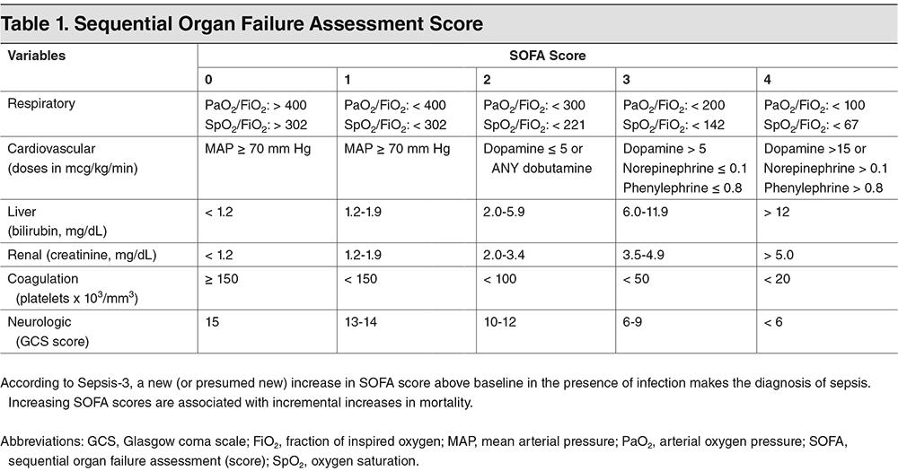

### qSOFA score

# Alcohol withdrawal

## Pathophsiology

Alcohol withdrawal occurs upon abrupt cessation of prolonged, sustained ethanol intake.

Abrupt cessation unmasks the adaptive responses to chronic ethanol use, resulting in **overactivity** of the central nervous system.

**Alochol is a CNS depressant**.

- It enhances GABA mediated inhibitory tone
- Suppresses excitatory tone.

Alcohol stimulates GABA but also makes the GABA receptors less sensitive with chronic use.  
A few weeks of continued usage is sufficient for this effect.  
When alcohol is stopped, GABA decreases but the desensitized receptors remain -> overall result is that the CNS is now insensitive to GABA -> overall increased excitation.

Glutamate is one of the **major excitatory amino acids**.  
Glutamade binds to the NMDA receptor -> calcium influx -> neuronal excitation.  
This is inhibited by alcohol.  
Adaptation occurs by increasing the expression of glutamate receptors; this adaptation is unmasked when alcohol with withdrawn -> hyperexcitability.

## Physiological effects of alcohol

Increased opiate levels -> euphoria  
Increases GABA -> anxiolytic and sedative effects.  
Inhibits glutamate receptor -> chonic use leads to glutamate receptor upregulation -> increased CNS excitability when alcohol is withdrawn.  
Neuronal death in the brain due to chornic alcohol use -> crebellar degeneration.

Alcohol withdrawal occurs in those who have maintained high intake for years and who maintain binges for weeks at a time.

> [!INFO] Predicting risk of withdrawal  
> The best predictor for clinically significant alcohol withdrawal is a Prediction of Alcohol Withdrawal Severity Scale **(PAWSS)** score
> - A score of ≥4 suggests high risk for moderate to severe AWS; prophylaxis and/or treatment may be indicated

## Symptoms of withdrawal

- Tremors of hands and legs
- Nausea and retching
- Sweating and tachycardia
- Hallucinations
- Epileptic seizures
- After about 48 hours -> delerium tremens.

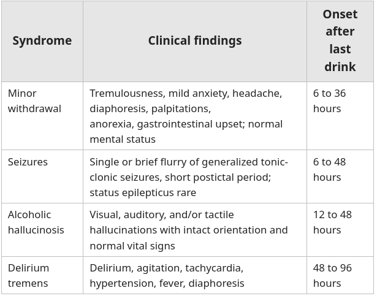

### Withdrawal seizures

1. Phenytoin it **NOT effective**
2. benzodiazepines -> phenobarbital -> porpofol should be used.

> [!TIP] Alcohol withdrawal seizures can be managed with phenoBARBIEtone

[figure not shown]

> [!INFO] Alcohol withdrawal seizures if untreated will progress to **delerium tremens** in 1/3 of cases

### Alcoholic hallucinosis

Usually visual; auditory hallucinations aren't impossible.  
Patients continue to have insight about the hallucinations, so they are usually distressed.

## Delerium tremens

> **rapid-onset**, *fluctuating* **disturbance of attention and cognition**, sometimes with hallucinations, in the presence of alcohol withdrawal
- accompanied by **agitation** and signs of extreme autonomic hyperactivity,
- including fever,
- severe tachycardia,
- hypertension,
- and drenching sweats

Patients with DT have significantly elevated cardiac indixes, oxygen delivery, and oxygen consumption.  
Hyperventilation is present -> causes hypocapnia -> decreased cerebral blood flow.

Other associated problems:

- Hypovolemia - vomitting, sweating, poor intake
- Metabolic acidosis - alcoholic ketoacidosis, hypoperfusion, or thiamine deficiency. (See [[causesOfLacticAcidosis.png]]
- hypokalemia - renal and extra renal pottasium losses; aldosterone alterations
- hypomagnesemia - predisposes to arrhythmia
- hypophophatemia - results from mulnutrition.

> [!WARNING] CAUSES OF DEATH  
> Death usually is due to *dysrhythmia, complicating illnesses such as pneumonia, or **failure to identify an underlying problem that led to the cessation of alcohol use***, such as pancreatitis, hepatitis, or central nervous system injury or infection.

## Treatment

Supportive - benzodiazepines to prevent progression of withdrawal symptoms.  
IV benzodiazepines if required.

Prophylactic chlordiazepoxide can be used if high risk of withdrawal in a patient admitted for other reasons.

#2022GM  
[More criteria](https://www.msdmanuals.com/professional/multimedia/table/modified-duke-clinical-diagnostic-criteria-for-infective-endocarditis)

#2022GM-MAY Q14

**Small vessel vasculitedes are divided into**  
3. MPA (Microscopic polyangitis) - no other name.  
most commonly affected organs are *upper and lower respiratory tract* and **kidneys**.  
**Kidney** - **rapidly proliferative *glomerulonephritis***.  
Kidneys: **Focal** *necrotizing* glomerulonephritis with *crescents and thrombosis*.